# Optimizing Warehousing and Logistics Strategies for E-commerce Enterprises

Ran Deng

```r
file_content <- readLines("dashboard.Rmd", encoding = "UTF-8")
file_content <- gsub("[^[:print:]]", "", file_content)
writeLines(file_content, "dashboard_clean.Rmd")
```

# Introduction

This project explores the warehousing and logistics strategies of small e-commerce enterprises, focusing on optimizing costs and delivery efficiency. The study investigates how warehouse location, order volume, and regional characteristics affect warehousing and logistics expenses. The study employs advanced quantitative models, including linear regression (LM), linear mixed models (LMM), and geographically weighted regression (GWR), to analyze global and spatial relationships in the data. Visualization tools such as bar charts, heat maps, and trend lines are used to effectively communicate key findings. The target audience of this project includes academic researchers, policymakers, and business professionals with intermediate to advanced expertise in e-commerce, supply chain management, or data analytics. The study aims to provide actionable insights for small business decision makers who may not have access to significant resources but seek to effectively improve logistics and warehousing strategies.

# Research Objectives

1. Analyze how warehouse location influences warehousing and delivery costs.
2. Use multiple statistical models (LM, LMM, and GWR) to explore spatial and non-spatial relationships.
3. Provide actionable insights for small businesses to optimize warehouse placement.

# Research Question

How can small e-commerce businesses optimize warehouse location and logistics strategies to minimize costs while improving delivery efficiency?

# Hypotheses

H1: Warehouses closer to major cities or demand centers can significantly reduce logistics costs. H2: Higher order volumes are positively correlated with logistics efficiency but also increase warehousing costs. H3: Regions with higher population density have more concentrated warehousing and delivery demand, impacting cost structures.

# Methodology

This project combines descriptive analytics, regression modeling, and geospatial analysis: 1. Data Visualization: Visualizes trends, demands, and costs. 2. Regression Models: LM, LMM, and GWR to uncover patterns and predictors. 3. Interactive Mapping: Highlights demand distributions across regions.

# LMI Trend Chart

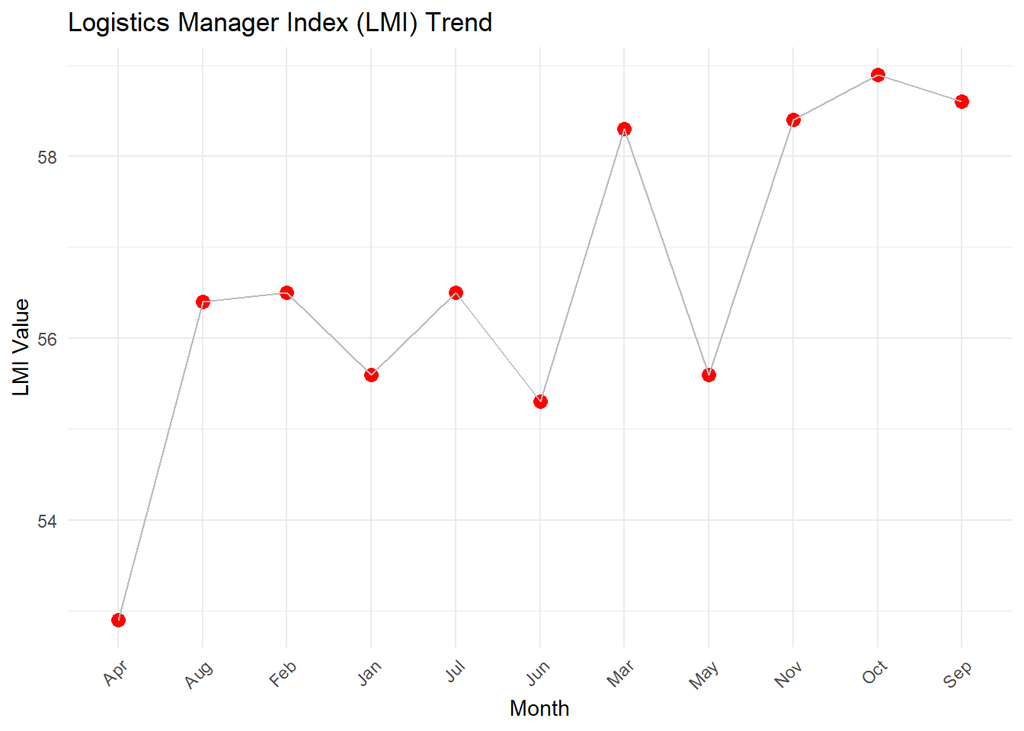

# Order Demand Distribution by Region

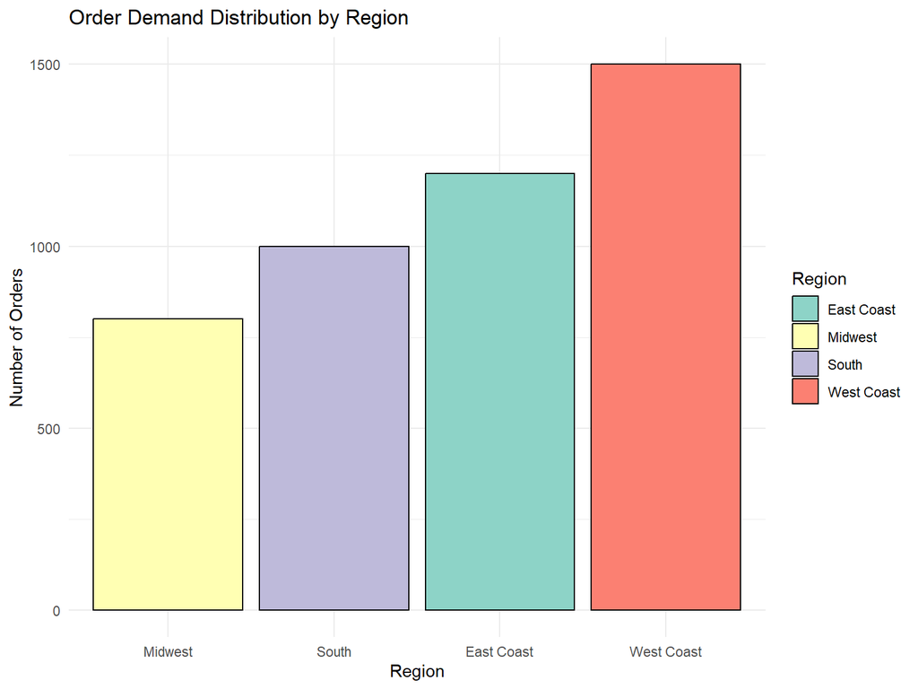

# Transportation Costs by Mode

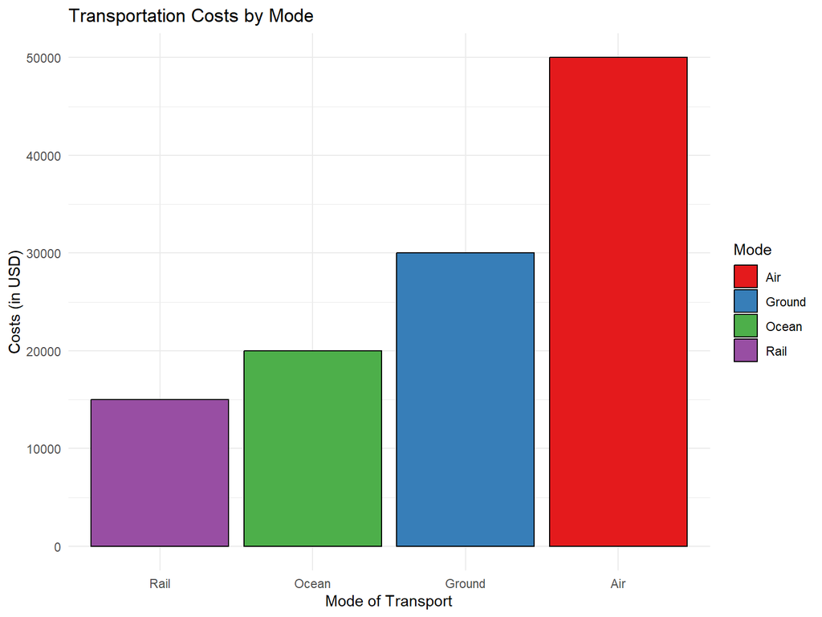

# Order Demand Chart

```r
# 安装并加载必要的包
if (!require(leaflet)) {
  install.packages("leaflet")
}
library(leaflet)

# 示例数据
order_data <- data.frame(
  Region = c("West Coast", "East Coast", "Midwest", "South"),
  Latitude = c(37.7749, 40.7128, 41.8781, 29.7604),  # 纬度
  Longitude = c(-122.4194, -74.0060, -87.6298, -95.3698),  # 经度
  Orders = c(1500, 1200, 800, 1000)  # 订单数量
)

# 动态生成颜色映射
order_data$color <- colorNumeric(
  palette = "Blues",
  domain = order_data$Orders
)(order_data$Orders)

# 生成交互式地图
leaflet(order_data) %>%
  addTiles() %>%  # 基础地图
  addCircleMarkers(
    lng = ~Longitude, lat = ~Latitude,
    radius = ~Orders / 100,  # 气泡大小与订单数量成比例
    color = ~color,          # 动态颜色
    fillOpacity = 0.6,
    popup = ~paste0("<b>Region:</b> ", Region, "<br><b>Orders:</b> ", Orders)
  ) %>%
  addLegend(
    position = "bottomright",
    title = "Order Demand",
    pal = colorNumeric(palette = "Blues", domain = order_data$Orders),
    values = ~Orders
  )
```

[interactive chart not shown]